## emr - Economic Models in R

Esta pacote tem o objetivo de possibilitar a definição e a execução de simulações de modelos de equilíbrio parcial e geral. A ideia é ser algo similar ao GAMS e GEMPACK.

A definição dos modelos segue a lógica discutida em [A simple structure for CGE models](https://jgea.org/resources/download/6539.pdf) by Xiao-guang Zhang.

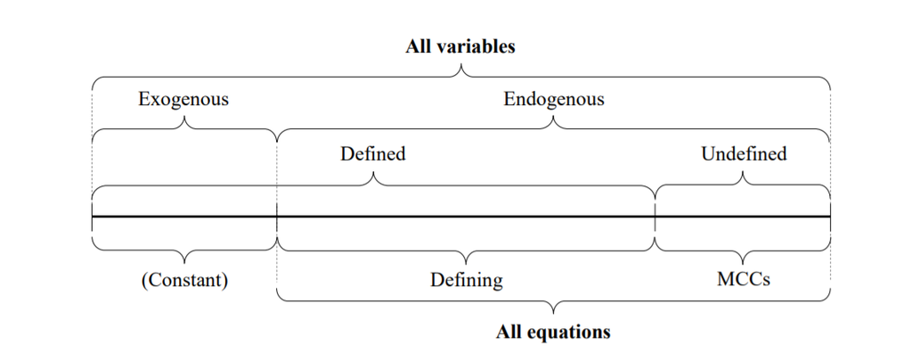

Structure of variables and equations (Zhang, 2013)

Nessa abordagem, as variáveis exógenas e endógenas serão classificadas em dois tipos: definidas ou não-definidas. As variáveis exógenas, por definição, são definidas. As endógenas pode ser dos dois tipos. As variáveis definidas são aquelas que podem ser construídas a partir dos valores das demais variáveis, das chamadas equação de definição. Já as não-definidas são aquelas que os valores serão definidos a partir de condições de equilíbrio de mercado (MCCs).

## Primeiro Exemplo - Modelo de Armington

O modelo de armington consiste no problema do consumidor que deve alocar sua renda em produtos de $N$ diferentes origens, que chamaremos de variedades. O consumidor tem uma função de utilidade do tipo CES com elasticidade de substituição. Dessa forma, o problema do consumidor é o seguinte:

$$\max_{{c_1,...,c_n}}U = \left[\sum_{i=1}^N\alpha_i^\frac{1-\sigma}{\sigma} c_i^\frac{\sigma-1}{\sigma}\right]^\frac{\sigma}{\sigma-1}$$

$$s.a. \sum_{i=1}^N p_ic_i = R,$$

onde $p_i = p_i^s(1+t_i)$ é o preço pago ao produtor adicionado de uma tarifa ad valorem $t_i$.

Resolvendo o problema do consumidor, chega-se a seguinte equação de demanda para a variedade $i$:

$$c_i = \left(\frac{\alpha_i p_i}{P}\right)^{-\sigma} Q$$
onde $Q=R/P$ e $P$ é o índice de preços da CES que tem a seguinte formula:

$$P = \left[\sum_i (\alpha_i p_i)^{1-\sigma}\right]^\frac{1}{1-\sigma}$$

Adicionalmente, pode-se definir uma função de demanda total do tipo elasticidade constante:

$$Q = k^d P^{\eta}$$

onde $\eta < 0$ é elasticidade-preço da demanda.

Por fim, a oferta de cada variedade também é dada por uma função do tipo elasticidade constante:

$$q_i = k^s \left(\frac{p_i}{1+t_i}\right)^{\epsilon_i}$$

Dessa forma, o sistema é formado por essas equações para as variáveis $Q$ (definida), $q_i$ (definida), $c_i$ (definida), $P$ (definida) e $p_i$ (não-definida):

- Demanda Total:

$$Q = k^d P^{\eta}$$

- Oferta da variedade $i$:

$$q_i = k^s \left(\frac{p_i}{1+t_i}\right)^{\epsilon_i}$$

- Demanda pela variedade $i$:

$$c_i = \left(\frac{\alpha_i p_i}{P}\right)^{-\sigma} Q$$

- Índice de preços:

$$P = \left[\sum_i (\alpha_i p_i)^{1-\sigma}\right]^\frac{1}{1-\sigma}$$

- Condição de equilíbrio (para a variável $p_i$):

$$c_i = q_i$$

Agora, vamos definir o modelo no R. Para isso, vamos escrever as equações em variações exatas. Isto é, a variação de uma variável $x$ entre o equilíbrio base e o novo equilíbrio ($x'$) é denotada por $\hat{x} = \frac{x'}{x}$.

Para construir o modelo, precisaremos definir os conjuntos de índices (por exemplo, o nome das regiões fornecedoras $i$), os parâmetros (acomoda parâmetros e variáveis exógenas), as variáveis e as equações.

```r
library(emr) #load the package!
library(tidyverse)
params <- list()
variables <- list()
equations <- list()
sets <- list()
```

### Sets

Começando pelo conjunto de índices:

```r
sets[['REG']] <-c("reg1", "reg2", "reg3")
```

### Parâmetros

Agora iremos definir os parâmetros:

```r
params[["sigma"]] <- create_param(
  value = 4,
  indexes = list(sigma = "sigma"),
  desc = "elasticity of substitution"
)

params[["eta"]] <- create_param(
  value = -1,
  indexes = list(eta = "eta"),
  desc = "price elasticity of total demand"
)

params[["epsilon"]] <- create_param(
  value = c(1, 10, 10),
  indexes = sets['REG'],
  desc = "price elasticity of individuals supplies"
)

params[["tau"]] <- create_param(
  value = c(1, 1, 1),
  indexes = sets['REG'],
  desc = "change in the tarrif power (1 + t)"
)

# v0 will be used to compute shares
params[["v0"]] <- create_param(
  value = c(60, 30, 10),
  indexes = sets['REG'],
  desc = "initial values"
)

params
```

```
## $sigma
## $sigma$value
## sigma
##     4
##
## $sigma$desc
## [1] "elasticity of substitution"
##
##
## $eta
## $eta$value
## eta
##  -1
##
## $eta$desc
## [1] "price elasticity of total demand"
##
##
## $epsilon
## $epsilon$value
## reg1 reg2 reg3
##    1   10   10
##
## $epsilon$desc
## [1] "price elasticity of individuals supplies"
##
##
## $tau
## $tau$value
## reg1 reg2 reg3
##    1    1    1
##
## $tau$desc
## [1] "change in the tarrif power (1 + t)"
##
##
## $v0
## $v0$value
## reg1 reg2 reg3
##   60   30   10
##
## $v0$desc
## [1] "initial values"
```

### Índice de Preços

$$\hat{P} = \left[\sum_i \pi_ip_i^{1-\sigma}\right]^\frac{1}{1-\sigma},$$

onde $\pi_i = \frac{v^0_i}{\sum_i v^0_i}$ é o share da variedade $i$ no dispêndio inicial. $v^0_i$ é o dispêndio inicial em cada variedade $i$.

```r
variables[["P"]] <- create_variable(
  value = 1,
  indexes = list(P = "P"),
  type = "defined",
  desc = "change in price index"
)

equations[["E_P"]] <- create_equation(
  "P = sum(v0/sum(v0) * p^(1-sigma))^(1/(1-sigma))",
  type = 'defining',
  desc = "change in demand for variety i"
)
```

### Demanda Total

$$\hat{Q} = \hat{P}^\eta$$

Inicialmente, é preciso definir as variáveis:

```r
variables[["Q"]] <- create_variable(
  value = 1,
  indexes = list(Q = "Q"),
  type = "defined",
  desc = "change in total demand"
)
```

E na sequência a equação:

```r
equations[["E_Q"]] <- create_equation(
  "Q = P^eta",
  type = "defining",
  desc = "change in total demand"
)
```

### Oferta

$$\hat{q}_i = \left(\frac{\hat{p_i}}{\hat{\tau_i}}\right)^{\epsilon_i}$$
onde $\hat{\tau_i} = \frac{1 + \hat{t_i}}{1 + t_i}$.

```r
variables[["q"]] <- create_variable(
  value = 1,
  indexes = sets['REG'],
  type = "defined",
  desc = "change in supply by region"
)

equations[["E_q"]] <- create_equation(
  "q[i] = (p[i]/tau[i])^epsilon[i]",
  indexes = 'i in REG',
  type = 'defining',
  desc = "change in supply by region"
)
```

### Demanda por variedade

$$\hat{c}_i = \left(\frac{\hat{p}_i}{\hat{P}}\right)^{-\sigma} \hat{Q}$$

```r
variables[["c"]] <- create_variable(
  value = 1,
  indexes = sets['REG'],
  type = "defined",
  desc = "change in demand for variety i"
)

equations[["E_c"]] <- create_equation(
  "c[i] = (p[i]/P)^(-sigma) * Q",
  indexes = 'i in REG',
  type = 'defining',
  desc = "change in demand for variety i"
)
```

### Equilíbrio de Mercado

$$\hat{q}_i = \hat{c}_i$$

```r
variables[["p"]] <- create_variable(
  value = 1,
  indexes = sets['REG'],
  type = "undefined",
  desc = "change in price (including tariff) of variety supplied by region i"
)

equations[["E_p"]] <- create_equation(
  "c[i] - q[i]",
  indexes = 'i in REG',
  type = "mcc",
  desc = "equilibrium for variety i"
)
```

### Objeto do Modelo

```r
armington_model <- list(
  sets = sets,
  params = params,
  variables = variables,
  equations = equations
)

sol0 <- solve_emr(armington_model)
```

```
## Iteration:  0  ||F(x0)||:  0
```

```r
armington_model$params$tau$value['reg2'] <- 1.1
sol1 <- solve_emr(armington_model, method = "nleqslv")

# Check the solution message
sol1$sol$message
```

```
## [1] "Function criterion near zero"
```

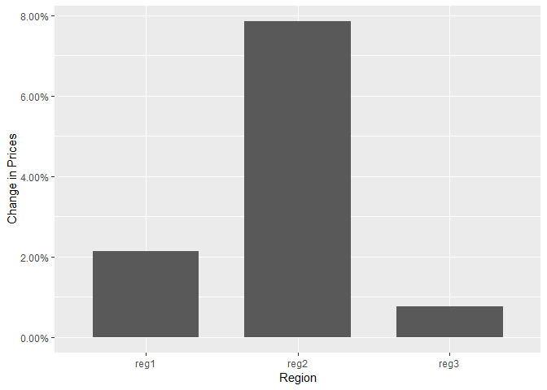

```r
# See the results for the internal prices
enframe(sol1$variables$p) %>%
  ggplot(aes(x = name, y = value - 1)) +
  geom_col(width = 0.7) +
  scale_y_continuous(labels = scales::percent) +
  labs(
    x = "Region",
    y = "Change in Prices"
  )
```